# Homework 4 Solutions

Here’s where each state ended up.

```r
km_res$cluster[order(km_res$cluster)]
```

```
##         Alaska        Arizona     California       Colorado        Florida
##              1              1              1              1              1
##       Illinois       Maryland       Michigan       Missouri         Nevada
##              1              1              1              1              1
##     New Mexico       New York          Texas    Connecticut       Delaware
##              1              1              1              2              2
##         Hawaii        Indiana         Kansas  Massachusetts     New Jersey
##              2              2              2              2              2
##           Ohio       Oklahoma         Oregon   Pennsylvania   Rhode Island
##              2              2              2              2              2
##           Utah       Virginia     Washington        Wyoming        Alabama
##              2              2              2              2              3
##       Arkansas        Georgia      Louisiana    Mississippi North Carolina
##              3              3              3              3              3
## South Carolina      Tennessee          Idaho           Iowa       Kentucky
##              3              3              4              4              4
##          Maine      Minnesota        Montana       Nebraska  New Hampshire
##              4              4              4              4              4
##   North Dakota   South Dakota        Vermont  West Virginia      Wisconsin
##              4              4              4              4              4
```

2. Fit a Gaussian Mixture Model (GMM) to the same data and compare the BIC for models with 2–6 clusters.

```r
gmm_res <- Mclust(X.scaled, G = 2:6)
summary(gmm_res)
```

```
## ----------------------------------------------------
## Gaussian finite mixture model fitted by EM algorithm
## ----------------------------------------------------
##
## Mclust VEI (diagonal, equal shape) model with 3 components:
##
##  log-likelihood  n df       BIC       ICL
##       -217.3636 50 20 -512.9677 -517.5878
##
## Clustering table:
##  1  2  3
## 20 10 20
```

```r
gmm_res$BIC
```

```
## Bayesian Information Criterion (BIC):
##         EII       VII       EEI       VEI       EVI       VVI       EEE
## 2 -538.8433 -540.8772 -527.0649 -528.6261 -535.4764 -537.2757 -526.5854
## 3 -537.5736 -525.7363 -526.2293 -512.9677 -543.7187 -527.7402 -532.9476
## 4 -521.7755 -526.6926 -517.8144 -519.4226 -543.1231 -543.7167 -534.2095
## 5 -533.2121 -538.0429 -531.1563 -534.6521 -561.6267 -564.2804 -548.5219
## 6 -550.2138 -545.5360 -548.2120 -550.4491 -577.6596 -595.8654 -566.1261
##         VEE       EVE       VVE       EEV       VEV       EVV       VVV
## 2 -523.2595 -526.9245 -528.7491 -525.2100 -527.3192 -535.5687 -537.8664
## 3 -523.1587 -524.2615 -534.9031 -518.3290 -540.6332 -533.7338 -537.8338
## 4 -532.9796 -532.6512 -541.8985 -553.6194 -567.6144 -559.0539 -585.2552
## 5 -550.5176 -560.2447 -573.9986 -579.1599 -586.9238 -604.4145 -618.2049
## 6 -564.7011 -591.5751 -590.6452 -590.6371 -600.8944 -629.8840 -642.2880
##
## Top 3 models based on the BIC criterion:
##     VEI,3     EEI,4     EEV,3
## -512.9677 -517.8144 -518.3290
```

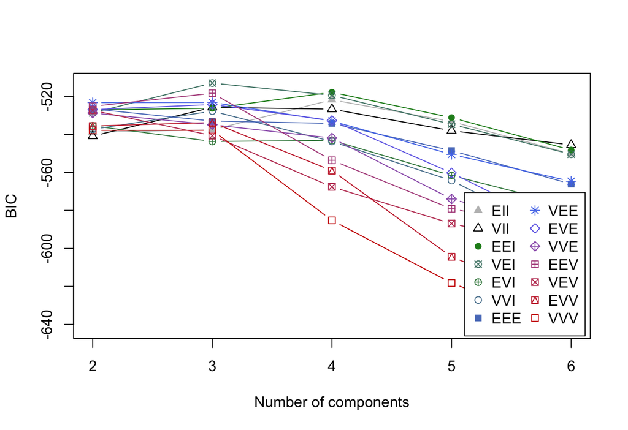

```r
plot(gmm_res, what = "BIC")
```

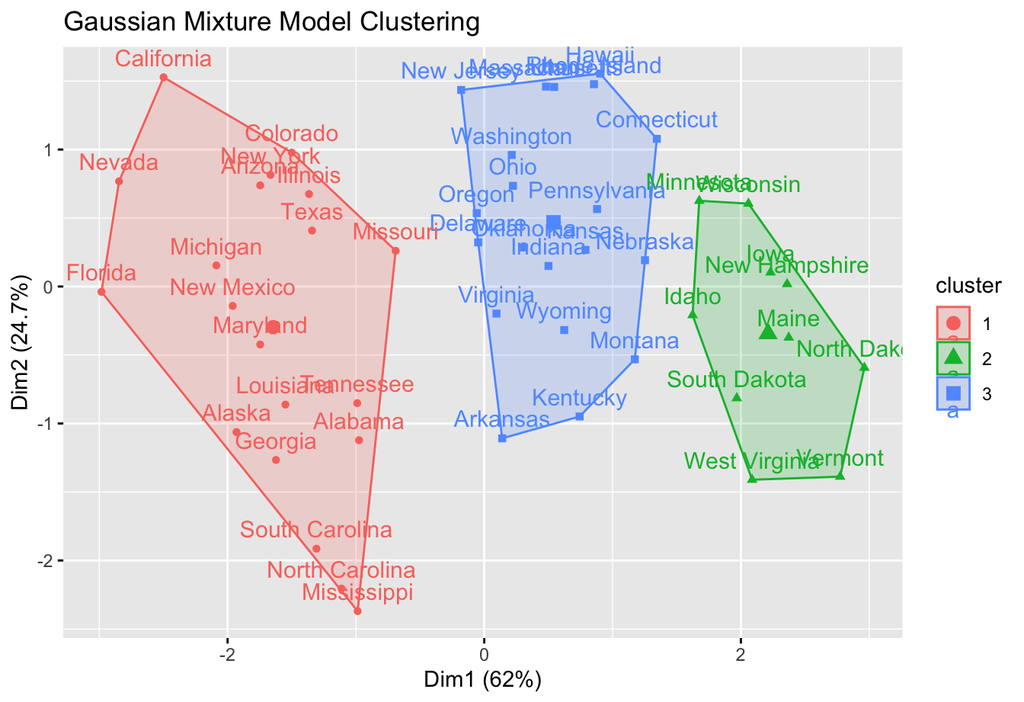

```r
fviz_cluster(list(data = X.scaled, cluster = gmm_res$classification)) +
  labs(title = "Gaussian Mixture Model Clustering")
```

Based on the results, the VEI structure with 3 clusters had the best BIC value. The figure shows that we did not need to look at more than 6 clusters as the BIC is clearly decreasing from 3 to 6.